# PRIVILEGED AND CONFIDENTIAL: Ethanol Growth Report

Geoffrey Zahn

23 May, 2022

# **Protocol:**

**Replication of Ewaze, *et al.*, 2008, Figure 4 - “Effect of ethanol vapour on dormant cell germination”**

Ewaze, J. O., Summerbell, R. C., & Scott, J. A. (2008). Ethanol physiology in the warehouse-staining fungus, Baudoinia compniacensis. Mycological Research, 112(11), 1373–1380. https://doi.org/10.1016/j.mycres.2008.05.003

**Design**

6 Treatments (Sterile control, Acetone 10ppm control, Ethanol 0.1ppm, Ethanol 1ppm, Ethanol 10ppm, Ethanol 100ppm)

5 replicate subjects per treatment

Grow dormant colonies on sterile filters for 14 days in vapor treatment chambers

Count resultant colonies on filters

Analyze with One-way ANOVA and GLM (Colony count ~ treatment)

**Short summary:**

- While it appears that ethanol at 1, 10, and 100 ppm increases *B. panamericana* germination, statistical tests are unable to conclude that these differences are significant and real.
- With the exception of a single 100 ppm jar which had 262 colonies growing, the remainder of samples had between 0 and 20 colonies.
- I have left that high-count jar in all analyses, but I am suspicious of why it did so much better than every other 100 ppm sample. It could be contamination with another carbon source, or just that biology is confusing.

# **Results:**

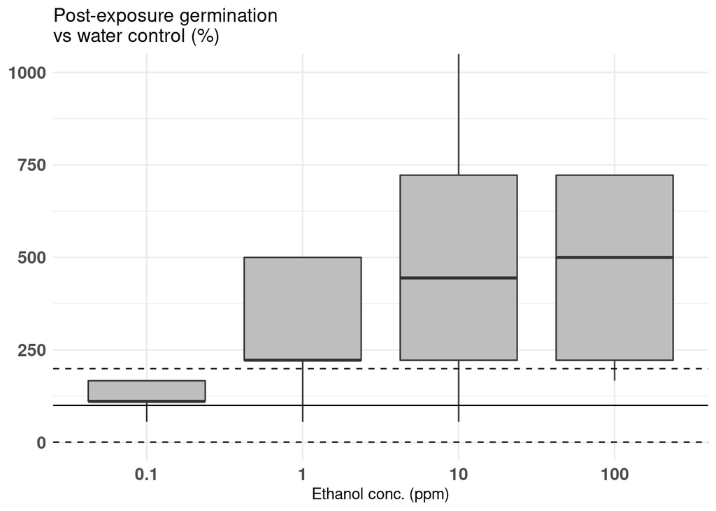

Figure 1.

I used several complimentary (redundant) statistical approaches to determine whether apparent differences (from Figure 1) were statistically significant. First, I ran a General Linear Regression on raw colony count data, using Ethanol concentration as a predictor. There was no significant difference between the treatments.

We fitted a linear model to predict colony_count with ppm. The model’s explanatory power is moderate (R2 = 0.18). The model’s intercept is at 1.80 (95% CI [-43.01, 46.61]). Within this model:

- The effect of ppm [0.1] is statistically non-significant and positive (beta = 0.40, 95% CI [-62.97, 63.77], t(20) = 0.01, p = 0.990, Std. beta = 7.75e-03)
- The effect of ppm [1] is statistically non-significant and positive (beta = 3.60, 95% CI [-59.77, 66.97], t(20) = 0.11, p = 0.912, Std. beta = 0.07)
- The effect of ppm [10] is statistically non-significant and positive (beta = 7.40, 95% CI [-55.97, 70.77], t(20) = 0.23, p = 0.821, Std. beta = 0.14)
- The effect of ppm [100] is statistically non-significant and positive (beta = 56.40, 95% CI [-6.97, 119.77], t(20) = 1.74, p = 0.096, Std. beta = 1.09)

Next, I ran the alternative approach of conducting individual T-tests between each Ethanol treatment and the sterile water controls. This series of tests agreed with the GLM approach.

| PPM | Water_Diff |
| --- | --- |
| 0.1 | FALSE |
| 1 | FALSE |
| 10 | FALSE |
| 100 | FALSE |

Lastly, I ran another linear regression model, but this time on transformed values instead of raw colony counts. In this case, relative colony counts were used (relative to the sterile water control mean colony count value). This was to better reflect what was visualized in Figure 1. Again, the model agreed that it is unable to determine significant differences between the different Ethanol treatments in their relative increase in germination over sterile water controls.

We fitted a linear model to predict Relative_germination with ppm. The model’s explanatory power is moderate (R2 = 0.17). The model’s intercept is at 1.98 (95% CI [-13.76, 17.73]). Within this model:

- The effect of ppm is statistically non-significant and positive (beta = 0.30, 95% CI [-9.66e-03, 0.62], t(18) = 1.90, p = 0.074, Std. beta = 0.41)